# Bios 301: Final Project

Yu Zhang

12/09/2014

*Due Tuesday, 9 December, 6:00 PM*

200 points total.

Submit a single knitr file (named `final.rmd`), along with a valid PDF output file. Add your name as `author` to the file’s metadata section. Raw R code/output or word processor files are not acceptable.

All work should be done by the student, please no collaboration. You may ask the instructor for help or clarification.

Obtain a copy of the [football-values lecture](https://github.com/couthcommander/football-values) – make sure to update this repository if you have previously cloned it. Save the six CSV files in your working directory (note the new file `nfl_current14.csv`). You may utilize [assignment 2, question 3](https://dl.dropboxusercontent.com/u/5044136/Bios301/homework2.rmd) in your solution.

## Task 1: Finding Residuals (80 points)

At the beginning of the course we examined projections for the 2014 NFL season. With the season ~65% completed, let’s compare the observed values to the estimated values. Place all code at the end of the instructions.

1. Read in the five projection files

   ```r
     k <- read.csv('proj_k14.csv', header=TRUE, stringsAsFactors=FALSE)
     qb <- read.csv('proj_qb14.csv', header=TRUE, stringsAsFactors=FALSE)
     rb <- read.csv('proj_rb14.csv', header=TRUE, stringsAsFactors=FALSE)
     te <- read.csv('proj_te14.csv', header=TRUE, stringsAsFactors=FALSE)
     wr <- read.csv('proj_wr14.csv', header=TRUE, stringsAsFactors=FALSE)
   ```

2. Add a column for position

   ```r
     k[,'pos'] <- 'k'
     qb[,'pos'] <- 'qb'
     rb[,'pos'] <- 'rb'
     te[,'pos'] <- 'te'
     wr[,'pos'] <- 'wr'
   ```

3. Combine these files

   ```r
     cols <- unique(c(names(k), names(qb), names(rb), names(te), names(wr)))
     k[,setdiff(cols, names(k))] <- 0
     qb[,setdiff(cols, names(qb))] <- 0
     rb[,setdiff(cols, names(rb))] <- 0
     te[,setdiff(cols, names(te))] <- 0
     wr[,setdiff(cols, names(wr))] <- 0
     x <- rbind(k[,cols], qb[,cols], rb[,cols], te[,cols], wr[,cols])
     names(x) <- gsub('[.]', '', names(x))
   ```

4. The projection data assumes teams play 16 games. The observed data is taken after week 11, where 30 teams have played 10 games, and 2 teams (`PIT` and `CAR`) have played 11. The projection data includes a column for a player’s team. In the projection data, multiply the numeric columns by percent of the season played (so 11/16 if team is PIT/CAR, otherwise, 10/16).

   ```r
     x[which(x$XTeam=='PIT' | x$XTeam=='CAR'),sapply(x, is.numeric)]<-x[which(x$XTeam=='PIT' | x$XTeam=='CAR'),sapply(x, is.numeric)]*11/16
     x[which(!(x$XTeam=='PIT' | x$XTeam=='CAR')),sapply(x, is.numeric)]<-x[which(!(x$XTeam=='PIT' | x$XTeam=='CAR')),sapply(x, is.numeric)]*10/16
   ```

5. Read in the observed data (`nfl_current14.csv`)

   ```r
     current <- read.csv('nfl_current14.csv', header=TRUE, stringsAsFactors=FALSE)
   ```

6. Merge the projected data with the observed data by the player’s name

   ```r
     total <- merge(x,current,by='PlayerName')
     total[which(total$PlayerName=='Dexter McCluster')[1],sapply(total, is.numeric)]<-colMeans(total[which(total$PlayerName=='Dexter McCluster'),sapply(total, is.numeric)])
     total[which(total$PlayerName=='Zach Miller')[1],sapply(total, is.numeric)]<-colMeans(total[which(total$PlayerName=='Zach Miller'),sapply(total, is.numeric)])
     total<-total[c(-which(total$PlayerName=='Dexter McCluster')[2],-which(total$PlayerName=='Zach Miller')[2]),]
     rownames(total) <- 1:nrow(total)
   # Here I merged the duplicate records by taking means of the two
   ```

7. Determine the proper mapping of categories in the projected data to the observed data. For instance, fg=>FGM, fga=>FGA, xpt=>XPM (the rest should be easy). Hint: there should be 15 mapped categories.

   ```r
     name.proj <- names(total)[c(3:5,8:19)]
     name.current<-c('FGM','FGA','XPM','Cmp.pass','Att.pass','Yds.pass','TD.pass','Int.pass','Att.rush','Yds.rush','TD.rush','Fmb','Rec.catch','Yds.catch','TD.catch')
   ```

8. Create the following vector `pred.pos <- c(k=20, qb=20, rb=40, wr=60, te=20)`. This is the number of players to examine at each position.

   ```r
     pred.pos <- c(k=20, qb=20, rb=40, wr=60, te=20)
   ```

9. Create a list of residual values by position

   ```r
     rv<-vector("list",length=5)
     names(rv) <- c('k','qb','rb','wr','te')
     criteria <- c('fg','pass_tds','rush_tds','rec_tds','rec_tds')
   ```

10. When subsetting by position, re-order the data as follows:
- if position = ‘k’, order by projected ‘fg’ descendingly
- if position = ‘qb’, order by projected ‘pass_tds’ descendingly
- if position = ‘rb’, order by projected ‘rush_tds’ descendingly
- if position = ‘wr’, order by projected ‘rec_tds’ descendingly
- if position = ‘te’, order by projected ‘rec_tds’ descendingly
  1. Reduce the subset to the number of rows given above. For instance, look at the top 40 ‘rb’, ordered by projected rushing touchdowns.
  2. Take the difference between the observed data and the projected data for each category. Thus, the residuals for ‘rb’ should be a 40x15 data.frame or matrix.

```r
    n <- 1
    for(i in names(rv)){
      rv[[i]]<-total[which(total$pos==i)[order(total[which(total$pos==i),criteria[n]],decreasing=TRUE)],][1:pred.pos[[i]],]
      rownames(rv[[i]]) <- NULL
      n <- n+1
    }

    for(i in names(rv)){
        n<-1
        for(j in name.proj){
          rv[[i]][[j]]<-rv[[i]][[name.current[n]]]-rv[[i]][[j]]
          n<-n+1
        }
        rv[[i]]<-rv[[i]][,name.proj]
      }
    # Here are the values for residual
    rv
```

```
## $k
##         fg     fga     xpt pass_att pass_cmp pass_yds pass_tds pass_ints
## 1  -1.9375 -1.3125  4.8750        0        0        0        0         0
## 2   3.6250  2.1875  3.5625        0        0        0        0         0
## 3   2.5625  0.3750  9.5625        0        0        0        0         0
## 4  -0.4375  1.4375 -6.0625        0        0        0        0         0
## 5   0.3125  0.0625 -0.6875        0        0        0        0         0
## 6  -2.4375 -4.1250 -1.3125        0        0        0        0         0
## 7  -1.1250  0.1250  2.8750        0        0        0        0         0
## 8  -2.1250 -2.6875  0.7500        0        0        0        0         0
## 9   0.1250 -0.4875  4.4312        0        0        0        0         0
## 10 -2.3750 -3.5000  5.2500        0        0        0        0         0
## 11  0.8813  2.1313 -4.4375        0        0        0        0         0
## 12  1.0625  1.7500 -8.0000        0        0        0        0         0
## 13 -8.6250 -9.1250 -3.8750        0        0        0        0         0
```

[output cut: 324 more lines]

#### Stub Answer

The result of task 1 is necessary to complete task 3. If you were unable to generate a list of residuals, please use the following code to simulate residuals. Otherwise, you do not need this code.

```r
pred.pos <- c(k=20, qb=20, rb=40, wr=60, te=20)
noise <- list()
empty <- data.frame(fg=0, fga=0, xpt=0, pass_att=0, pass_cmp=0, pass_yds=0, pass_tds=0, pass_ints=0,
                    rush_att=0, rush_yds=0, rush_tds=0, fumbles=0, rec_att=0, rec_yds=0, rec_tds=0)
for(i in names(pred.pos)) {
  noise[[i]] <- empty[rep(1,pred.pos[i]),]
  row.names(noise[[i]]) <- NULL
}
set.seed(35)
noise$k$fg <- rnorm(20, 0, 3)
noise$k$fga <- rnorm(20, 0, 4)
noise$k$xpt <- rnorm(20, 0, 5)
noise$qb$pass_att <- rnorm(20, 0, 25)
noise$qb$pass_cmp <- rnorm(20, 0, 15)
noise$qb$pass_yds <- rnorm(20, 0, 150)
noise$qb$pass_tds <- rnorm(20, 0, 4)
noise$qb$pass_ints <- rnorm(20, 0, 2)
noise$rb$rush_att <- rnorm(40, 0, 40)
noise$rb$rush_yds <- rnorm(40, 0, 200)
noise$rb$rush_tds <- rnorm(40, 0, 2)
noise$rb$fumbles <- rnorm(40, 0, 1)
noise$wr$rec_att <- rnorm(60, 0, 10)
noise$wr$rec_yds <- rnorm(60, 0, 160)
noise$wr$rec_tds <- rnorm(60, 0, 2)
noise$te$rec_att <- rnorm(20, 0, 10)
noise$te$rec_yds <- rnorm(20, 0, 120)
noise$te$rec_tds <- rnorm(20, 0, 2)
```

## Task 2: Creating League S3 Class (80 points)

Create an S3 class called `league`. Place all code at the end of the instructions.

1. Create a function `league` that takes 5 arguments (`stats`, `nteams`, `cap`, `pos`, `points`)
- Inside the function, save the `stats` argument as an element of a list
- The other arguments can also be saved on the list, or saved as attributes of the list
- Define the class of the list as `league`
- Add another list element, `fan_pnts`, which is assigned the output of function `calcPoints` (defined below)
- Add another list element, `values`, which is assigned the output of function `buildValues` (defined below)
- Add another list element, `sims`, and assign it to NULL
- Return the list (which should be a S3 class now)
- It’s worth mentioning that in OOP terminology, `stats`, `fan_pnts`, `values`, and `sims` are attributes of the `league` class. This may be confusing as any R variable may have attributes (see ?attr or ?attributes). Henceforth, I will simply refer to `stats`, etc as list elements. `nteams`, `cap`, `pos`, and `points` will either be list elements or list attributes (depending on how you define your class), and I will refer to them as settings.
1. Create a function `calcPoints` that takes 1 argument, a league object
- Use the `stats` list element and the `points` setting from the league object
- Calculate points for each stat category by multiplying that stat by its respective point multiplier
- Create a new column `Points`, which is the sum of all the points categories
- Order the data set by `Points` descendingly
- Return the data set with the following columns: `PlayerName`, `XTeam`, `pos`, `Points`
- Note this will be assigned to the `fan_pnts` list element
1. Create a function `buildValues` that takes 1 argument, a league object
- Use the `fan_pnts` list element and the `nteams`, `cap`, and `pos` settings
- Order the data set by `Points` descendingly
- Create a new column `marg`
- Order the data set by `marg` descendingly
- Create a new column `value`
- Return the data set with the following columns: `PlayerName`, `XTeam`, `pos`, `Points`, `marg`, `value`
- Note this will be assigned to the `values` list element
1. Create a `print` method for the league class
- Print the `values` list element
1. Create a `plot` method for the league class
- Plot the `value` column of the `values` list element
- Add minimal plotting decorations (such as axis labels)
- Here’s an example:

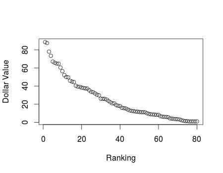

1. Create a `boxplot` method for the league class
- Run `boxplot` of `value` by `pos` from the `values` list element
- Add minimal plotting decorations
- Here’s an example:

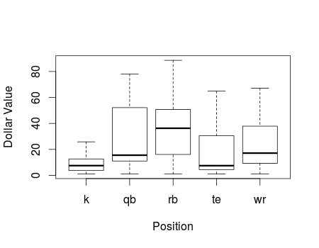

1. Create a `hist` method for the league class
- Run `hist` on the `value` column of the `values` list element
- Add minimal plotting decorations
- Here’s an example:

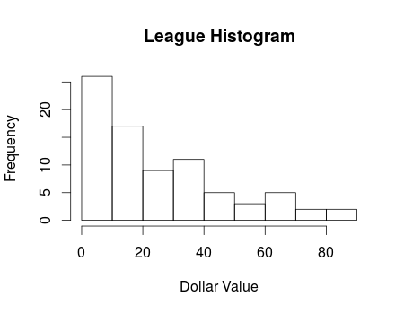

I will test your code with additional league settings (using the same projection data). I will try some things that should work and some things that should break. Don’t be too concerned, but here’s some things I might try:

- Not including all positions
- Including new positions that don’t exist
- Requiring no players at a position
- Requiring too many players at a position (ie - there aren’t 100 kickers)

Note that at this point it should be easy to change a league setting (such as `nteams`) and re-run `calcPoints` and `buildValues`.

```r
  calcPoints <- function(lgobj){
    lgobj$stats[,"Points"] <- 0
    for(i in names(lgobj$points)){
      lgobj$stats[,"Points"] <- lgobj$stats[,"Points"]+lgobj$stats[[i]]*lgobj$points[[i]]
    }
    lgobj$stats <- lgobj$stats[order(lgobj$stats[,'Points'], decreasing=TRUE),][,c("PlayerName","XTeam","pos","Points")]
    return(lgobj$stats)
  }

  buildValues <- function(x2){
    x2$fan_pnts <- x2$fan_pnts[order(x2$fan_pnts[,'Points'], decreasing=TRUE),]
    ix <- vector('list',length(x2$pos))
    names(ix)<-names(x2$pos)
    x2$fan_pnts[,'marg']<- NA
    for(i in names(ix)){
      ix[[i]]<-which(x2$fan_pnts[,'pos']==i)
      if(x2$pos[[i]]>0){
        x2$fan_pnts[ix[[i]],'marg']<-x2$fan_pnts[ix[[i]],'Points']-x2$fan_pnts[ix[[i]][pos[[i]]*x2$nteams],'Points']
      }
    }
    x3<-x2$fan_pnts[x2$fan_pnts[,'marg'] >= 0 & !is.na(x2$fan_pnts[,'marg']),]
    x3 <- x3[order(x3[,'marg'], decreasing=TRUE),]
    rownames(x3) <- NULL
    x3[,'value'] <- x3[,'marg']*(x2$nteams*x2$cap-nrow(x3))/sum(x3[,'marg']) + 1
    x3<-x3[,c('PlayerName', 'XTeam', 'pos', 'Points', 'marg', 'value')]
    return(x3)
  }

  league <- function(stats,nteams,cap,pos,points){
    stl <- list(stats,nteams,cap,pos,points)
    names(stl)<-c('stats','nteams','cap','pos','points')
    stl$fan_pnts <-calcPoints(stl)
    stl$values<-buildValues(stl)
    stl<-append(stl,list(sims=NULL))
    class(stl) <- "league"
    return(stl)
  }

  print.league <- function(x){
    cat("The values for players:\n")
    print(x$values)
  }

  plot.league <- function(x){
    plot(x$values$value,xlab="Ranking",ylab="Dollar Value")
  }

  boxplot.league <- function(x){
    boxplot(x$values$value~x$values$pos,xlab="position",ylab="Dollar Value")
  }

  hist.league <- function(x){
    hist(x$values$value,main="League Histogram",xlab="Dollar Value",ylab="Frequency")
  }
```

Test:

```r
pos <- list(qb=1, rb=2, wr=3, te=1, k=1)
pnts <- list(fg=4, xpt=1, pass_yds=1/25, pass_tds=4, pass_ints=-2,              rush_yds=1/10, rush_tds=6, fumbles=-2, rec_yds=1/20, rec_tds=6)
l <- league(x, 10, 200, pos, pnts)
l
```

```
## The values for players:
##               PlayerName XTeam pos Points     marg  value
## 1         Jamaal Charles    KC  rb 148.11 53.64375 88.824
## 2           LeSean McCoy   PHI  rb 147.46 52.99375 87.759
## 3         Peyton Manning   DEN  qb 226.50 45.36112 75.264
## 4        Adrian Peterson   MIN  rb 138.86 44.39375 73.680
## 5         Calvin Johnson   DET  wr  93.46 40.46563 67.249
## 6             Matt Forte   CHI  rb 134.09 39.62812 65.878
## 7       Demaryius Thomas   DEN  wr  92.05 39.05938 64.947
## 8           Jimmy Graham    NO  te  85.26 37.48750 62.373
## 9          Aaron Rodgers    GB  qb 215.76 34.61863 57.676
## 10            Eddie Lacy    GB  rb 128.43 33.96563 56.607
## 11          Le'Veon Bell   PIT  rb 128.31 33.84937 56.417
## 12           Julio Jones   ATL  wr  82.99 30.00000 50.115
## 13            Dez Bryant   DAL  wr  82.81 29.82187 49.823
```

[output cut: 67 more lines]

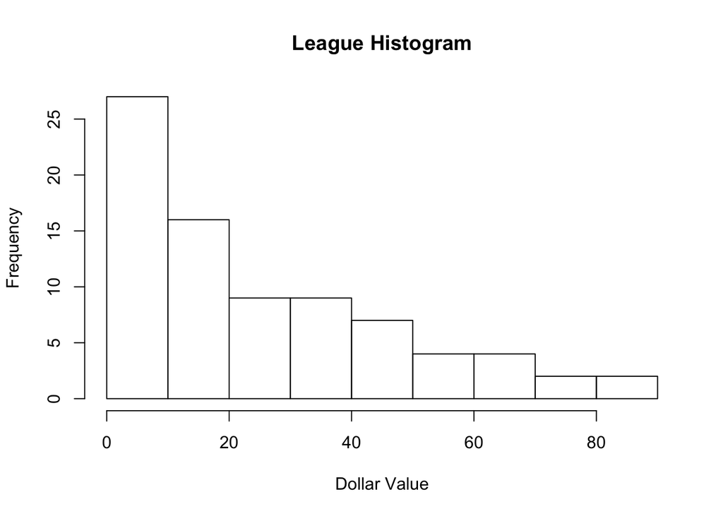

```r
hist(l)
```

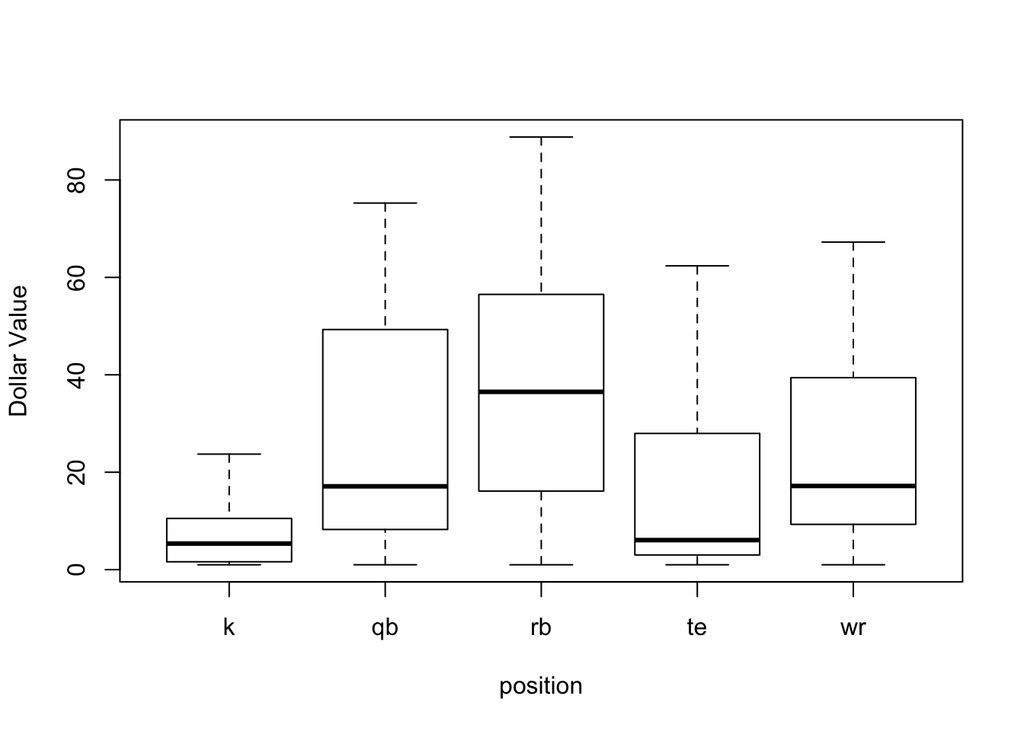

```r
boxplot(l)
```

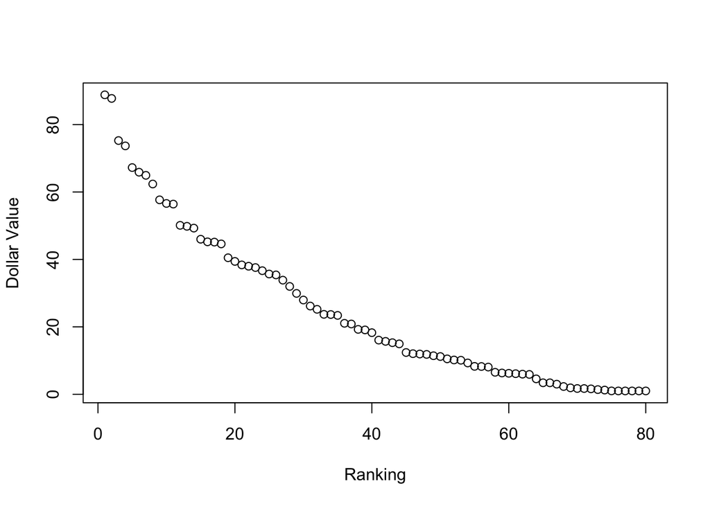

```r
plot(l)
```

## Task 3: Simulations with Residuals (40 points)

Using residuals from task 1, create a list of league simulations to save in the list element `sims`. The simulations will be used to generate confidence intervals for player values. Place all code at the end of the instructions.

1. Create a function `addNoise` that takes 4 arguments: a league object, a list of residuals, number of simulations to generate, and a RNG seed
- Use the `stats` list element and the `pos` setting
- Set a RNG seed to ensure reproducability
- For each simulation iterate over each position in the residuals
- Simulate new stats for the given position
- Assume residuals is a list, and the ‘qb’ element contains a 20x15 matrix
- Calculate the number of quarterbacks found in `stats` - assume this is 35 (which is not real value)
- Sample from 1 to 20 (with replacement) 35 times
- Use the sample of 35 to select rows from the residuals
- Add the 35 rows of residuals to the 35 rows of stats
- Note: stats can’t be negative so replace any negative values with 0
- Use the new, simulated stats data set and the old league settings to generate a new league object
- Save the `values` list element of the new league object in a list for each simulation
- Merge the list of values by `PlayerName`
- Start with the `stats` data set, using the “PlayerName”, “XTeam”, “pos” columns
- `value` is the only column you need to merge from `values`
- Remember that the `values` list element only has rows for the number of required players while the `stats` list element has rows for all projected players. Thus some players will have values in some simulations, but not in others. When merging, set a player’s value to 0 if he is not found in the `values` list element.
- If 1000 simulations are requested, you should end up with a data frame with 1003 columns
- Assign the merged values data set to the `sims` list element (of the original league object)
- Return the league object
1. Create a `quantile` method for the league class; it takes at least two arguments, a league object and a probs vector
- This method requires the `sims` list element; it should fail if `sims` is NULL
- The `probs` vector should default to `c(0.25, 0.5, 0.75)`
- Run `quantile` for each row, passing it `probs` (and any additional arguments)
- Return a data set with columns for “PlayerName”, “XTeam”, “pos”, and for each probability
1. Create a function `conf.interval`; it takes at least two arguments, a league object and a probs vector
- This method requires the `sims` list element; it should fail if `sims` is NULL
- Use the `nteams` and `pos` settings
- Call `quantile` on the league object
- Iterate over each position, saving results as a list
- Subset the output of quantile by position
- Order this data set by the last column (which should be the highest probability) descendingly
- Restrict the number of rows to the number of required players at this position
- Set the class of this list to `league.conf.interval`
- Return the new object
1. Create a `plot` method for the league.conf.interval class; it takes at least two arguments, a league.conf.interval object and a position
- Select the list element that matches the position - this data set holds the quantile values for each player
- Plot lines for each probability; using the defaults, you would have three lines (0.25, 0.5, 0.75)
- Add minimal plotting decorations (such as axis labels)
- Add a legend to distinguish each line
- Here’s an example:

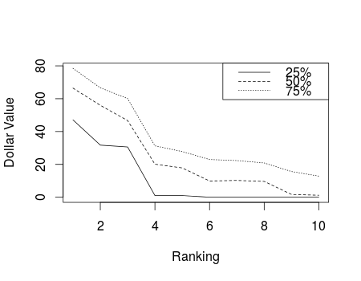

```r
  addNoise <- function(l,rv,num,seed=100){
    set.seed(seed)
    nos<-vector("list",length(rv))
    names(nos)<-names(rv)
    results<-cbind(PlayerName=l$stats$PlayerName,XTeam=l$stats$XTeam,pos=l$stats$pos)
    data <- data.frame(matrix(0,nrow=nrow(l$stats),ncol=num))
    names(data)<-paste("simulation", 1:num, sep="")
    results<-cbind(results,data)
    for(n in 1:num){
    for(i in names(nos)){
      nos[[i]]<-length(which(l$stats$pos==i))
      l$stats[which(l$stats$pos==i),names(rv[[i]])]<-l$stats[which(l$stats$pos==i),names(rv[[i]])]+rv[[i]][sample(1:nrow(rv[[i]]),nos[[i]],replace=TRUE,prob=NULL),]
    }
    l$stats[,sapply(l$stats,is.numeric)][l$stats[,sapply(l$stats,is.numeric)]<0]<-0
    l<-league(l$stats,l$nteams,l$cap,l$pos,l$points)
    for(i in 1:nrow(l$values)){
      results[results[,"PlayerName"]==l$values$PlayerName[i],n+3]<-l$values$value[i]
    }
    }
    l$sims<-results
    return(l)
  }

  quantile.league <- function(l,probs=c(0.25, 0.5, 0.75)){
    temp <- data.frame(t(apply(l$sims[,4:length(l$sims)],1,quantile,probs=c(0.25, 0.5, 0.75))))
    names(temp)<-c("25%","50%","75%")
    quant <-cbind(PlayerName=l$stats$PlayerName,XTeam=l$stats$XTeam,pos=l$stats$pos,temp)
    return(quant)
  }

  conf.interval <- function(l,probs=c(0.25, 0.5, 0.75)){
    temp<-quantile(l)
    temp<-temp[order(temp[,ncol(temp)], decreasing=TRUE),]
    qout<-vector("list",length=length(l$pos))
    names(qout)<-names(l$pos)
    for(i in names(qout)){
      qout[[i]]<-temp[which(temp[,"pos"]==i)[seq(l$nteams*l$pos[[i]])],]
      row.names(qout[[i]])<-NULL
    }
    class(qout) <- "league.conf.interval"
    return(qout)
  }

  plot.league.conf.interval <- function(qout,position){
    plot(c(1,10),c(0,qout[[position]][1,"75%"]+10),xlab="Ranking",ylab="Dollar Value",main=paste("quantile values for",position))
    lines(seq(nrow(qout[[position]])),qout[[position]][,"75%"],lty=3)
    lines(seq(nrow(qout[[position]])),qout[[position]][,"50%"],lty=2)
    lines(seq(nrow(qout[[position]])),qout[[position]][,"25%"],lty=1)
    legend('topright',c("25%","50%","75%"),lty=c(1,2,3))
  }
```

Here I just use a small number of simulations to test my code. It will take long time for 10000 simulations

```r
l1 <- addNoise(l, rv, 1000)
quantile(l1)
```

```
##                  PlayerName XTeam pos    25%     50%     75%
## 1        Stephen Gostkowski    NE   k  0.000   0.000   3.371
## 2               Phil Dawson    SF   k  0.000   0.000   4.190
## 3             Justin Tucker   BAL   k  0.000   0.000  12.808
## 4               Matt Prater   DEN   k  0.000   0.000   9.827
## 5              Mason Crosby    GB   k  0.000   0.000   7.698
## 6           Steven Hauschka   SEA   k  0.000   0.000   4.877
## 7            Adam Vinatieri   IND   k  0.000   0.000   1.240
## 8                Dan Bailey   DAL   k  0.000   0.000   0.000
## 9             Shayne Graham    NO   k  0.000   0.000   0.000
## 10               Nick Novak    SD   k  0.000   1.000  10.333
## 11              Matt Bryant   ATL   k  0.000   0.000   0.000
## 12             Robbie Gould   CHI   k  0.000   0.000   0.000
## 13              Alex Henery   PHI   k  0.000   0.000   2.259
## 14              Blair Walsh   MIN   k  0.000   0.000   0.000
```

[output cut: 603 more lines]

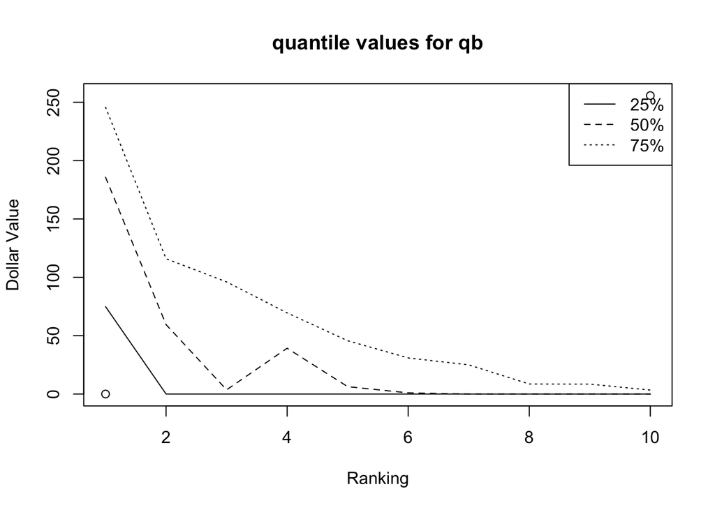

```r
ci <- conf.interval(l1)
plot(ci, 'qb')
```

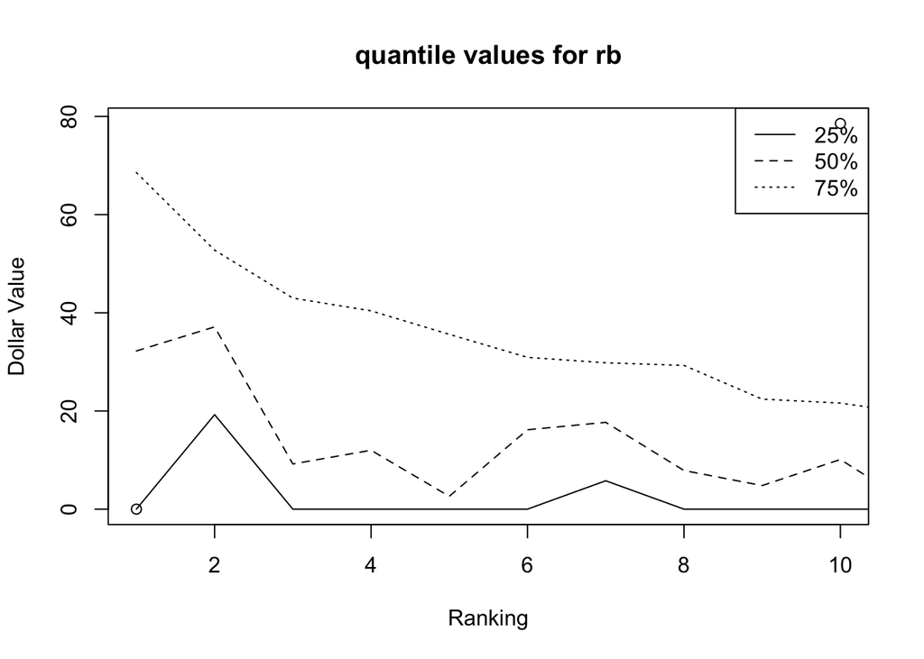

```r
plot(ci, 'rb')
```

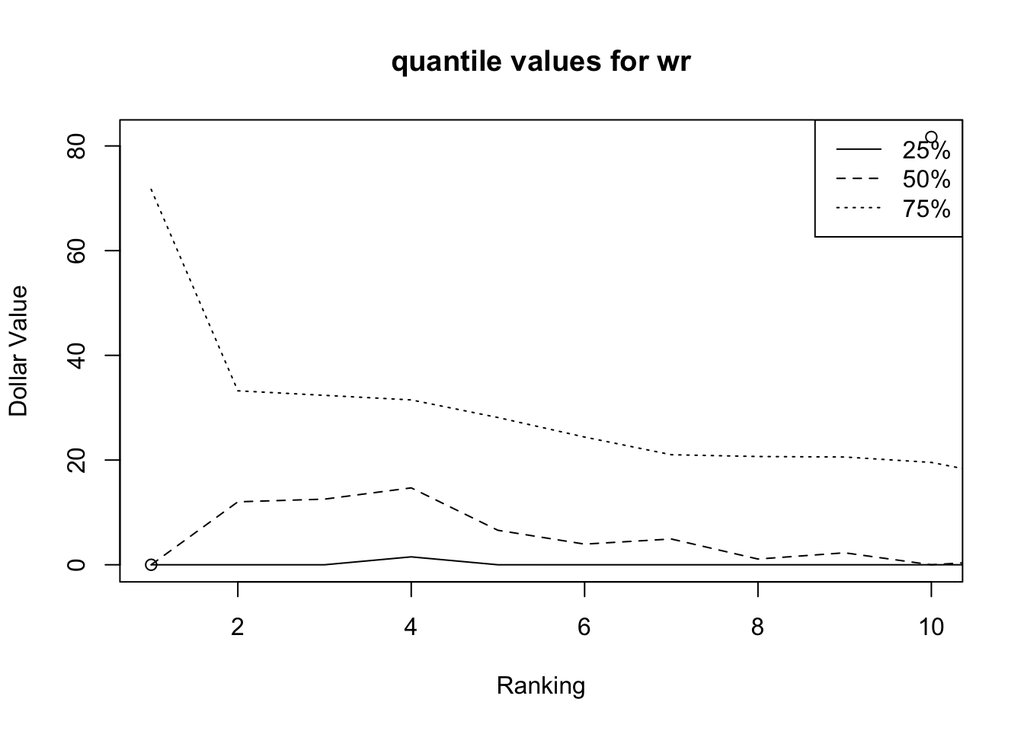

```r
plot(ci, 'wr')
```

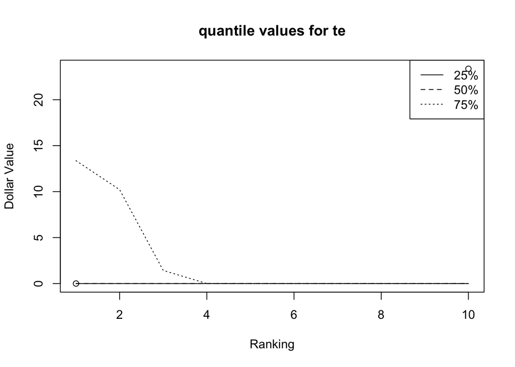

```r
plot(ci, 'te')
```

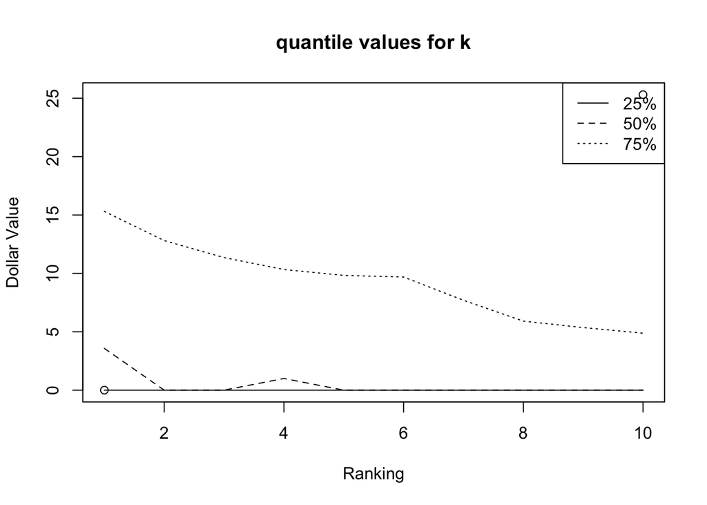

```r
plot(ci, 'k')
```

I will test your code with the following:

```r
l1 <- addNoise(l, noise, 10000)
quantile(l1)
ci <- conf.interval(l1)
plot(ci, 'qb')
plot(ci, 'rb')
plot(ci, 'wr')
plot(ci, 'te')
plot(ci, 'k')
```

## Additional Tips

This project is intentionally difficult. Use your best judgement in interpreting my instructions, and please do not hesitate to ask for clarification.

My expectation is that you complete tasks 1 and 2 - you have most of the code for this, it’s a matter of restructuring it.

If you’re stuck, use a stub answer, explain your algorithm, why it fails, and move on. Attempt everything.